# How can we control the increasing number of accidents in New York?

```python
import json
import requests
from bs4 import BeautifulSoup
import pandas as pd
import matplotlib.pyplot as plt
import seaborn as sns
import numpy
from itertools import chain, repeat# first use on exercise 4 to make a list with repetitions
```

## Introduction

**Business Context.** The city of New York has seen a rise in the number of accidents on the roads in the city. They would like to know if the number of accidents have increased in the last few weeks. For all the reported accidents, they have collected details for each accident and have been maintaining records for the past year and a half (from January 2018 to August 2019).

The city has contracted you to build visualizations that would help them identify patterns in accidents, which would help them take preventive actions to reduce the number of accidents in the future. They have certain parameters like borough, time of day, reason for accident, etc. Which they care about and which they would like to get specific information on.

**Business Problem.** Your task is to format the given data and provide visualizations that would answer the specific questions the client has, which are mentioned below.

**Analytical Context.** You are given a CSV file (stored in the already created `data` folder) containing details about each accident like date, time, location of the accident, reason for the accident, types of vehicles involved, injury and death count, etc. The delimiter in the given CSV file is `;` instead of the default `,`. You will be performing the following tasks on the data:

1. Extract additional borough data stored in a JSON file
2. Read, transform, and prepare data for visualization
3. Perform analytics and construct visualizations of the data to identify patterns in the dataset

The client has a specific set of questions they would like to get answers to. You will need to provide visualizations to accompany these:

1. How have the number of accidents fluctuated over the past year and a half? Have they increased over the time?
2. For any particular day, during which hours are accidents most likely to occur?
3. Are there more accidents on weekdays than weekends?
4. What are the accidents count-to-area ratio per borough? Which boroughs have disproportionately large numbers of accidents for their size?
5. For each borough, during which hours are accidents most likely to occur?
6. What are the top 5 causes of accidents in the city?
7. What types of vehicles are most involved in accidents per borough?
8. What types of vehicles are most involved in deaths?

## Fetching the relevant data

The client has requested analysis of the accidents-to-area ratio for boroughs. Borough data is stored in a JSON file in the `data` folder.

### Question :

Use the function `json.load()` to load the file `borough_data.json` as a dictionary.

**Answer.**

```python
with open("data/borough_data.json", "r") as read_file:
    dataBorough = json.load(read_file)
```

### Question :

Similarly, use the pandas function `read_csv()` to load the file `accidents.csv` as a DataFrame. Name this DataFrame `df`.

**Answer.**

```python
df = pd.read_csv("data/accidents.csv", delimiter = ";")
df.head()
df.shape
```

```
(238522, 24)
```

## Overview of the data

Let's go through the columns present in the dataframe:

```python
df.columns
```

```
Index(['DATE', 'TIME', 'BOROUGH', 'ZIP CODE', 'LATITUDE', 'LONGITUDE',
       'ON STREET NAME', 'NUMBER OF PEDESTRIANS INJURED',
       'NUMBER OF PEDESTRIANS KILLED', 'NUMBER OF CYCLIST INJURED',
       'NUMBER OF CYCLIST KILLED', 'NUMBER OF MOTORIST INJURED',
       'NUMBER OF MOTORIST KILLED', 'CONTRIBUTING FACTOR VEHICLE 1',
       'CONTRIBUTING FACTOR VEHICLE 2', 'CONTRIBUTING FACTOR VEHICLE 3',
       'CONTRIBUTING FACTOR VEHICLE 4', 'CONTRIBUTING FACTOR VEHICLE 5',
       'COLLISION_ID', 'VEHICLE TYPE CODE 1', 'VEHICLE TYPE CODE 2',
       'VEHICLE TYPE CODE 3', 'VEHICLE TYPE CODE 4', 'VEHICLE TYPE CODE 5'],
      dtype='object')
```

We have the following columns

1. **BOROUGH**: The borough in which the accident occured
2. **COLLISION_ID**: A unique identifier for this collision
3. **CONTRIBUTING FACTOR VEHICLE (1, 2, 3, 4, 5)**: Reasons for the accident
4. **CROSS STREET NAME**: Nearest cross street to the place of accidents
5. **DATE**: Date of the accident
6. **TIME**: Time of accident
7. **LATITUDE**: Latitude of the accident
8. **LONGITUDE**: Longitude of the accident
9. **NUMBER OF (CYCLISTS, MOTORISTS, PEDESTRIANS) INJURED**: Category wise injury
10. **NUMBER OF (CYCLISTS, MOTORISTS, PEDESTRIANS) KILLED**: Category wise death
11. **ON STREET NAME**: Street where the accident occured
12. **VEHICLE TYPE CODE (1, 2, 3, 4, 5)**: Types of vehicles involved in the accident
13. **ZIP CODE**: zip code of the accident location

### Exercise 1 :

Since 2014, New York City has been implementing a road safety plan named [Vision Zero](https://www1.nyc.gov/content/visionzero/pages/). It aims to reduce the number of traffic deaths to *zero* by the end of 2024. The plan is creating new and enhancing current safety measures, some of these include:

- [ ] Automated pedestrian detection
- [x] Road safety audits at high risk locations
- [ ] Expansion in the cycle track network
- [x] Targeted education and awareness initiatives
- [x] Creation of pedestrian refuge islands
- [x] Launch Integrated Data-Driven Speed Reducer Program (speed humps & speed cushions)

Which of these initiatives could directly benefit from an analysis of the data provided? Check all that apply.

**Note:** You can create check marks by double-clicking this cell and adding an `[x]` in the corresponding lines.

**Answer.**

The analysis of these historical accident data allows to have a better control in the allocation of resources, because we know the streets in which we know places of moderate to high risk.  
Road safety audits benefit from this analysis because the strategic points to carry out this intervention are known. The educational activities that are part of the road safety strategy could also benefit from use in places with high accidents.  
On the other hand, the analysis of this data set can provide us with information on the impact of each road actor in terms of accident rate / mortality and this impacts the application of specific measures for cyclists, motorcyclists and pedestrians.

Let's go ahead and answer each of the client's questions.

## Answering the client's questions

### Exercise 2 :

Group the available data on a monthly basis and generate a line plot of accidents over time. Has the number of accidents increased over the past year and a half?

**Hint**: You may find the pandas functions `to_datetime()` and `dt.to_period()` useful.

**Answer.**

```python
df['DATE'] = pd.to_datetime(df.DATE) # Converting to date format
dfMonth = (df.
           set_index('DATE')
           .to_period('M')
           .groupby('DATE')
           .size()
          )
```

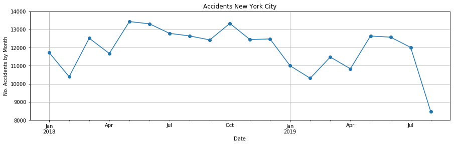

```python
plot1 = (dfMonth
         .plot(marker = 'o', figsize=(15,4), grid=True)
         .set(xlabel='Date', ylabel='No. Accidents by Month',
              title='Accidents New York City',
              ylim=(8000, 14000))
        )
```

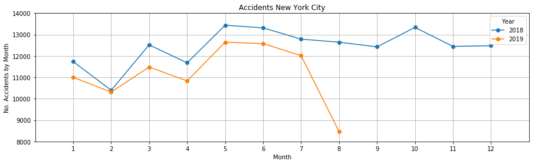

```python
dfMonth1 = (dfMonth
            .reset_index()
            .rename(columns = {'DATE':'Date', 0:'Sum_Accidents'}))
#
dfMonth1['Year']  = dfMonth1['Date'].dt.to_timestamp().apply(lambda x: x.year)
dfMonth1['Month'] = dfMonth1['Date'].dt.to_timestamp().apply(lambda x: x.month)
#
#
dfMonth2 = dfMonth1.pivot(index='Month', columns='Year', values='Sum_Accidents')
#
plot2 = (dfMonth2[[2018, 2019]]
         .plot(figsize=(15,4), marker = 'o', grid=True)
         .set(xlabel='Month', ylabel='No. Accidents by Month',
              title='Accidents New York City',
              xlim=(0,13), ylim=(8000, 14000),
              xticks=range(1,13,1)))
```

### Exercise 3 :

From the plot above, which months seem to have the least number of accidents? What do you think are the reasons behind this?

**Answer.**

### Exercise 4 :

How does the number of accidents vary throughout a single day? Create a new column `HOUR` based on the data from the `TIME` column, then plot a bar graph of the distribution per hour throughout the day.

**Hint:** You may find the function `dt.hour` useful.

**Answer.**

```python
df['HOUR'] = pd.to_datetime(df['TIME']).dt.hour
#
hourSummary = (df['HOUR']
               .value_counts()
               .reset_index()
               .sort_values(by = 'index')
               .rename(columns = {'index':'Hour', 'HOUR':'Sum_Accidents'})
              )
```

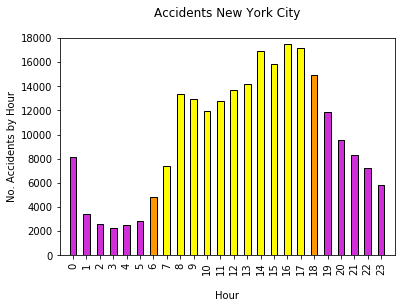

```python
dayHourLS = list(chain(repeat('#d02ed9', 6), ['#ff9500'], repeat('#fffb00', 11), ['#ff9500'], repeat('#d02ed9', 5)))
#
plot3 = (hourSummary
         .plot(x = 'Hour', y = 'Sum_Accidents', kind='bar', legend=False, rot = 90,
              color = dayHourLS, edgecolor ='black')
         .set(xlabel='\nHour', ylabel='No. Accidents by Hour',
              title='Accidents New York City\n',
              xlim=(-1,24), ylim=(0, 1.8E4),
              xticks=range(0,24,1)))
```

From this, we see that more accidents occur in the afternoon (2 - 6 PM) than at other times of day.

### Exercise 5 :

In the above question we have aggregated the number accidents per hour disregarding the date and place of ocurrence. Which criticism would you give to this approach?

**Answer.**

With this approach, the hours in which most accidents occur in the city are known, and this can be related to behaviors and mobility patterns. Although the aforementioned information is valuable, other aspects should be known regarding the date of the year and place to improve the location of the program's resources.

### Exercise 6 :

How does the number of accidents vary throughout a single week? Plot a bar graph based on the accidents count by day of the week.

**Hint:** You may find the function `dt.weekday` useful.

**Answer.**

```python
df['wd'] = df['DATE'].dt.weekday + 1
```

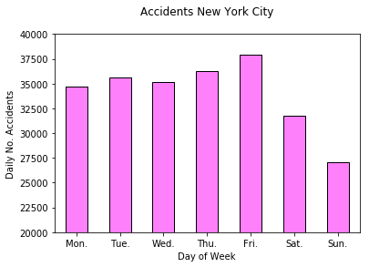

```python
wdSummary = (df['wd']
             .value_counts()
             .reset_index()
             .rename(columns = {'index':'Week_Day', 'wd':'Sum_Accidents'})
             .sort_values(by = 'Week_Day')
             .reset_index(drop = True)
            )
#

week_labels = ['Mon.', 'Tue.', 'Wed.', 'Thu.', 'Fri.', 'Sat.', 'Sun.']

plot4 = (wdSummary
         .plot(x = 'Week_Day', y = 'Sum_Accidents', kind='bar', legend=False,  rot = 0,
               color='#ff80fb', edgecolor='black')
         .set(xlabel='Day of Week', ylabel='Daily No. Accidents',
              xticklabels = week_labels,
              title='Accidents New York City\n', ylim=(2E4, 4.0E4))
        )
```

There are no important variations in the accident rate on weekdays except for weekends, when the accident rate drops significantly.

### Exercise 7 :

Plot a bar graph of the total number of accidents in each borough, as well as one of the accidents per square mile per borough. What can you conclude?

**Hint:** You may want to update some of the keys in the borough dictionary to match the names in the dataframe.

**Answer.**

```python
# Transpose
boroughDF = pd.DataFrame(dataBorough).T
boroughDF.index.name = 'BOROUGH'
boroughDF.reset_index(inplace=True)
```

```python
boroughDF['BOROUGH'] = boroughDF['BOROUGH'].map(lambda x: x.upper())
boroughDF['BOROUGH'] = boroughDF['BOROUGH'].map(lambda x: x.replace('THE ', ''))
boroughDF
```

|  | BOROUGH | area | name | population |
| --- | --- | --- | --- | --- |
| 0 | BRONX | 42.1 | the bronx | 1.47116e+06 |
| 1 | BROOKLYN | 70.82 | brooklyn | 2.64877e+06 |
| 2 | MANHATTAN | 22.83 | manhattan | 1.66473e+06 |
| 3 | QUEENS | 108.53 | queens | 2.35858e+06 |
| 4 | STATEN ISLAND | 58.37 | staten island | 479458 |

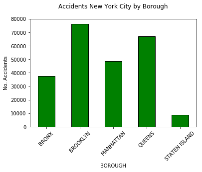

```python
boroughSummary = (
    df['BOROUGH']
    .value_counts()
    .reset_index()
    .rename(columns = {'index':'BOROUGH', 'BOROUGH':'Sum_Accidents'})
    .sort_values(by = 'BOROUGH')
    .reset_index(drop = True)
)
#
plot5 = (boroughSummary
         .plot(x = 'BOROUGH', y = 'Sum_Accidents', kind='bar', legend=False, rot=45,
               color='green', edgecolor='black')
         .set(ylabel='No. Accidents',
              title='Accidents New York City by Borough\n')
        )
```

```python
totalDF = pd.merge(boroughSummary, boroughDF, how='left', on='BOROUGH')
#
totalDF['Accidents_perSQM'] = totalDF['Sum_Accidents'] / totalDF['area']
totalDF
```

|  | BOROUGH | Sum_Accidents | area | name | population | Accidents_perSQM |
| --- | --- | --- | --- | --- | --- | --- |
| 0 | BRONX | 37709 | 42.1 | the bronx | 1.47116e+06 | 895.701 |
| 1 | BROOKLYN | 76253 | 70.82 | brooklyn | 2.64877e+06 | 1076.72 |
| 2 | MANHATTAN | 48749 | 22.83 | manhattan | 1.66473e+06 | 2135.3 |
| 3 | QUEENS | 67120 | 108.53 | queens | 2.35858e+06 | 618.447 |
| 4 | STATEN ISLAND | 8691 | 58.37 | staten island | 479458 | 148.895 |

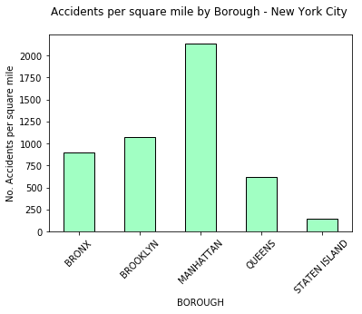

```python
plot6 = (totalDF
        .plot.bar(x = 'BOROUGH', y = 'Accidents_perSQM', legend=False, rot = 45,
                  color = '#a1ffc3', edgecolor = 'black')
        .set(ylabel='No. Accidents per square mile',
              title='Accidents per square mile by Borough - New York City \n')
        )
```

**Plot 5** shows that boroughs with the highest accident rates are Brookyln and Queens with respect to the absolute number of accidents. But a look at the accidents by land area (in square miles) for each borough in **Plot 6** shows that a higher proportion of accidents occur in Manhattan, and that could be caused by high mobility in this area. The second indicator should be better (for assessing accident rate) because it takes into account the number of streets on each borough.

### Exercise 8 :

Which hours have the most accidents for each borough? Plot a bar graph for each borough showing the number of accidents for each hour of the day.

**Hint:** You can use `sns.FacetGrid` to create a grid of plots with the hourly data of each borough.

**Answer.**

```python
totalDF1 = pd.merge(df, boroughDF, how='left', on='BOROUGH')
totalDF2 = (totalDF1
            .groupby(['BOROUGH', 'HOUR'])
            .size()
            .reset_index()
            .rename(columns = {0:'Sum_Accidents'})
           )
totalDF2.head()
```

|  | BOROUGH | HOUR | Sum_Accidents |
| --- | --- | --- | --- |
| 0 | BRONX | 0 | 1329 |
| 1 | BRONX | 1 | 529 |
| 2 | BRONX | 2 | 402 |
| 3 | BRONX | 3 | 361 |
| 4 | BRONX | 4 | 418 |

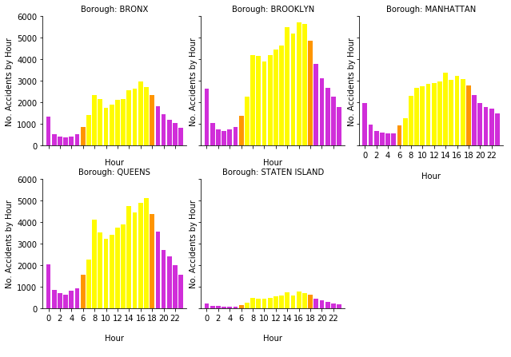

```python
PLOT7 = (
    sns.FacetGrid(totalDF2, col='BOROUGH', col_wrap=3)
    .map(plt.bar, 'HOUR', 'Sum_Accidents', color = dayHourLS)
    .set(xlabel='\nHour\n', ylabel='No. Accidents by Hour',
         xlim=(-1,24), ylim=(0, 6E3), xticks=range(0,24,2))
    .set_titles('Borough: {col_name}')
)
```

**Is the number of accidents higher at different times in different boroughs? Should we concentrate at different times for each borough?**

We can see that in all the boroughs the accident count is highest from approximately 2 - 6PM. But in Manhattan and the Bronx, you can see that there is not as much of a relative increase during these hours as in Brooklyn or Queens. Additionally, Staten Island has the lowest overall number of accidents.

### Exercise 9 :

What factors cause the most accidents? Avoid double counting the contributing factors of a single accident.

**Hint:** One way of dealing with repetitions is to concatenate the corresponding columns while preserving their indexes, you can do that with the functions `pd.concat()` and `reset_index()`. Then, use an appropiate `groupby` to count the number of repetitions of contributed factors per accident.

**Answer.**

```python
factorSeries = pd.concat([totalDF1['CONTRIBUTING FACTOR VEHICLE 1'],
                          totalDF1['CONTRIBUTING FACTOR VEHICLE 2'],
                          totalDF1['CONTRIBUTING FACTOR VEHICLE 3'],
                          totalDF1['CONTRIBUTING FACTOR VEHICLE 4'],
                          totalDF1['CONTRIBUTING FACTOR VEHICLE 5']],
                         ignore_index = False, axis = 0).reset_index().rename(columns = {0:'CONTRIBUTING FACTOR'})

factorSeries1 = (factorSeries
                 .groupby(['index', 'CONTRIBUTING FACTOR'])
                 .size()
                 .reset_index()
                 .rename(columns = {0:'COUNT_PER_ACCIDENT'})
                 .groupby('CONTRIBUTING FACTOR')
                 .size()
                 .sort_values(ascending=False)
                )
# Top 10 Factors contributing to accidents
factorSeries1[1:10]
```

```
CONTRIBUTING FACTOR
Driver Inattention/Distraction    61752
Failure to Yield Right-of-Way     19641
Following Too Closely             17293
Backing Unsafely                  14835
Passing Too Closely               12631
Passing or Lane Usage Improper    11808
Other Vehicular                    8860
Unsafe Lane Changing               6643
Turning Improperly                 6626
dtype: int64
```

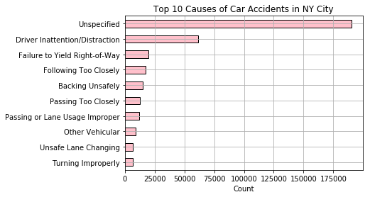

```python
PLOT8 = (factorSeries1
         .reset_index(name = 'Count')
         .iloc[0:10,:]
         .sort_values(by = 'Count')
         .plot.barh(y = 'Count', x = 'CONTRIBUTING FACTOR', legend=False,
                    color = 'pink', edgecolor = 'black', grid = True)
         .set(ylabel='', xlabel='Count',
              title = 'Top 10 Causes of Car Accidents in NY City')
        )
```

### Exercise 10 :

Which vehicle types are most involved in accidents per borough? Avoid double counting the type of vehicles present in a single accident.

**Hint:** You can apply a similar approach to the one used in the previous question.

**Answer.**

```python
vehicleSeries = (pd.concat([totalDF1['BOROUGH'],
                            totalDF1['VEHICLE TYPE CODE 1'],
                            totalDF1['VEHICLE TYPE CODE 2'],
                            totalDF1['VEHICLE TYPE CODE 3'],
                            totalDF1['VEHICLE TYPE CODE 4'],
                            totalDF1['VEHICLE TYPE CODE 5']],
                           ignore_index = False, axis = 1)
                )

vehicleSeries = vehicleSeries.apply(lambda x: x if x.name=='BOROUGH' else x.str.lower(), )
```

```python
vehicleSeries1 = (vehicleSeries
                  .reset_index()
                  .melt(
                      id_vars = ['index', 'BOROUGH'],
                      value_vars = [f'VEHICLE TYPE CODE {i+1}' for i in range(5)]
                  )
                 )
```

```python
vehicleSeries2 = (vehicleSeries1
                  .groupby(['BOROUGH', 'index', 'value'])
                  .size()
                  .reset_index(name='Count_per_Vehicle')
                  .groupby(['BOROUGH', 'value'])
                  .size()
                  .reset_index(name='Count_per_Vehicle')
                  .sort_values(by=['BOROUGH', 'Count_per_Vehicle'], ascending=[True, False])
                 )
vehicleSeries2.groupby('BOROUGH').head(10)
```

|  | BOROUGH | value | Count_per_Vehicle |
| --- | --- | --- | --- |
| 155 | BRONX | sedan | 19652 |
| 167 | BRONX | station wagon/sport utility vehicle | 15434 |
| 134 | BRONX | passenger vehicle | 4941 |
| 164 | BRONX | sport utility / station wagon | 3751 |
| 137 | BRONX | pick-up truck | 2093 |
| 172 | BRONX | taxi | 2058 |
| 23 | BRONX | box truck | 1098 |
| 28 | BRONX | bus | 1055 |
| 17 | BRONX | bike | 687 |
| 183 | BRONX | tractor truck diesel | 570 |
| 425 | BROOKLYN | sedan | 39459 |
| 441 | BROOKLYN | station wagon/sport utility vehicle | 32262 |
| 394 | BROOKLYN | passenger vehicle | 10177 |
| 437 | BROOKLYN | sport utility / station wagon | 8099 |
| 398 | BROOKLYN | pick-up truck | 3986 |
| 450 | BROOKLYN | taxi | 2754 |
| 252 | BROOKLYN | box truck | 2367 |
| 245 | BROOKLYN | bike | 2354 |
| 259 | BROOKLYN | bus | 1819 |
| 482 | BROOKLYN | van | 840 |
| 689 | MANHATTAN | sedan | 20727 |
| 702 | MANHATTAN | station wagon/sport utility vehicle | 16432 |
| 708 | MANHATTAN | taxi | 11955 |
| 662 | MANHATTAN | passenger vehicle | 5627 |
| 697 | MANHATTAN | sport utility / station wagon | 4415 |
| 528 | MANHATTAN | box truck | 3545 |
| 667 | MANHATTAN | pick-up truck | 2953 |
| 521 | MANHATTAN | bike | 2060 |
| 536 | MANHATTAN | bus | 1840 |
| 741 | MANHATTAN | van | 1186 |
| 918 | QUEENS | sedan | 35103 |
| 932 | QUEENS | station wagon/sport utility vehicle | 31647 |
| 895 | QUEENS | passenger vehicle | 8952 |
| 927 | QUEENS | sport utility / station wagon | 7890 |
| 897 | QUEENS | pick-up truck | 3912 |
| 937 | QUEENS | taxi | 2268 |
| 777 | QUEENS | box truck | 1458 |
| 774 | QUEENS | bike | 1092 |
| 784 | QUEENS | bus | 1063 |
| 951 | QUEENS | tractor truck diesel | 567 |
| 1036 | STATEN ISLAND | sedan | 4773 |
| 1040 | STATEN ISLAND | station wagon/sport utility vehicle | 3371 |
| 1027 | STATEN ISLAND | passenger vehicle | 1531 |
| 1038 | STATEN ISLAND | sport utility / station wagon | 904 |
| 1028 | STATEN ISLAND | pick-up truck | 694 |
| 993 | STATEN ISLAND | bus | 93 |
| 987 | STATEN ISLAND | bike | 71 |
| 1023 | STATEN ISLAND | motorcycle | 66 |
| 1043 | STATEN ISLAND | taxi | 47 |
| 990 | STATEN ISLAND | box truck | 41 |

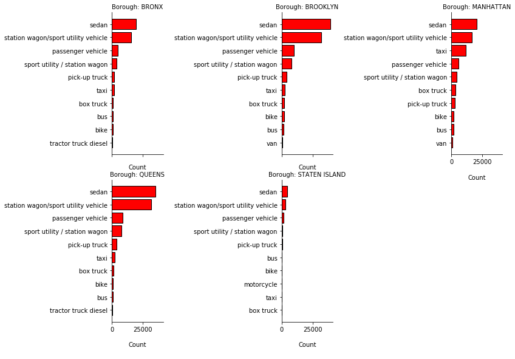

```python
PLOT9 = (
    sns.FacetGrid(vehicleSeries2.groupby('BOROUGH').head(10)
                  .sort_values(by=['BOROUGH', 'Count_per_Vehicle'], ascending=[True, True]),
                  height = 4,
#                   aspect = 15/4,
                  col='BOROUGH', col_wrap=3, sharey=False)
    .map(plt.barh, 'value', 'Count_per_Vehicle', color = 'red', edgecolor='black')
    .set(xlabel='\nCount\n', ylabel='', title = 'Main Vehicles Involved')
    .set_titles('Borough: {col_name}')
)
```

### Exercise 11 :

In a 2018 [interview](https://www.nytimes.com/2019/01/01/nyregion/traffic-deaths-decrease-nyc.html) with The New York Times, New York's mayor de Blasio stated that *'Vision Zero is clearly working'*. That year, the number of deaths in traffic accidents in NYC dropped to a historical 202. Yet, as reported by [am New York Metro](https://www.amny.com/news/vision-zero-de-blasio-1-30707464/), the number of fatalities has increased by 30% in the first quarter of 2019 compared to the previous year and the number of pedestrians and cyclist injured has not seen any improvement.

How would you use the provided data to understand what went wrong in the first quarter of 2019?

> - [ ] Consider the accidents of the first quarter of 2019. Then, check for the most common causes of accidents where pedestrians and cyclists were involved. Give a recommendation based solely on this information.
> - [X] Create a pair of heatmaps of the accidents involving injured/killed pedestrians and cyclists in the first quarter of 2018 and 2019. Compare these two to see if there is any change in the concentration of accidents. In critical areas, study the type of factors involved in the accidents. Give a recommendation to visit these areas to study the problem further.
> - [ ] The provided data is insufficient to improve our understanding of the situation.
> - [ ] None of the above. I would do the following: *here your recommended answer*.

**Answer.**

Although some localized interventions were carried out thanks to data analysis, monitoring should continue in other areas. If the critical areas previously identified continue to represent a risk for road actors, it must be evaluated whether the interventions have been effective or not in these places.

### Exercise 12 :

Calculate the number of deaths caused by each type of vehicle. Plot a bar chart for the top 5 vehicles. Which vehicles are most often involved in deaths, and by how much more than the others?

**For example,** if two people died at an accident where 5 vehicles were involved: 4 are PASSENGER VEHICLE and 1 is a SPORT UTILITY/STATION WAGON. Then, we would add two deaths to each PASSENGER VEHICLE and SPORT UTILITY/STATION WAGON types.

**Hint:** You may want to create a new column with the total number of kills in the accident. For that you may find the function `.to_numpy()` useful. Then, proceed as the previous excercises to avoid double-counting the type of vehicles.

**Answer.**

```python
totalDF1['totalDeaths'] = (totalDF1[['NUMBER OF PEDESTRIANS KILLED',
                                     'NUMBER OF CYCLIST KILLED',
                                     'NUMBER OF MOTORIST KILLED']]
                           .values
                           .sum(axis=1))
```

```python
deathSeries = (pd.concat([totalDF1['totalDeaths'],
                          totalDF1['VEHICLE TYPE CODE 1'],
                          totalDF1['VEHICLE TYPE CODE 2'],
                          totalDF1['VEHICLE TYPE CODE 3'],
                          totalDF1['VEHICLE TYPE CODE 4'],
                          totalDF1['VEHICLE TYPE CODE 5']],
                          ignore_index = False, axis = 1)
                )
deathSeries = deathSeries.apply(lambda x: x if x.name=='totalDeaths' else x.str.lower(), )
```

```python
deathSeries1 = (deathSeries
                .reset_index()
                .melt(
                    id_vars = ['index', 'totalDeaths'],
                    value_vars = [f'VEHICLE TYPE CODE {i+1}' for i in range(5)])
               )

deathSeries2 = (deathSeries1
                .groupby(['index', 'totalDeaths', 'value'])
                .size()
                .reset_index(name='Count_per_Vehicle')
                .groupby(['value']).sum().sort_values(by='totalDeaths',ascending=0)
                .drop(['index', 'Count_per_Vehicle'], axis = 1)
               )

deathSeries2.head(10)
```

| value | totalDeaths |
| --- | --- |
| station wagon/sport utility vehicle | 87 |
| sedan | 65 |
| motorcycle | 23 |
| passenger vehicle | 21 |
| sport utility / station wagon | 20 |
| bike | 19 |
| pick-up truck | 12 |
| bus | 10 |
| box truck | 8 |
| taxi | 6 |

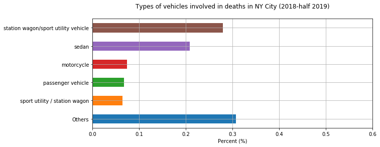

```python
#Lumping levels
deathSeries3 = pd.concat([deathSeries2.iloc[0:5,:].reset_index(),
                          pd.DataFrame({
                              'value': 'Others',
                              'totalDeaths' : deathSeries2.iloc[5:, :].sum()}
                          )]
                        ).reset_index(drop=True)

deathSeries3['Percentage'] = deathSeries3.totalDeaths/deathSeries3.totalDeaths.sum()



PLOT10 = (deathSeries3
          .sort_index(ascending = 0)
          .plot(x='value', y = 'Percentage', figsize=(10,4), grid=True, kind='barh', legend = False)
          .set(xlabel='Percent (%)', ylabel='',
               title='Types of vehicles involved in deaths in NY City (2018-half 2019)\n',
               xlim=(0, 0.6))
)
```